# ANOVA and linear models

Manpreet S. Katari

## Comparison of ANOVA with linear models

Recall that **planned** experiments are when you have control or a reference level in a factor that you want to always compare to. An **unplanned** experiment is when there is no base or control, and you simply want to know if there is a difference in the means of the different groups.

Here we will investigate the R commands that will allow us to test these two different types of experiments.

### Two samples with the same variance

Let’s generate two sample groups, *ctrl* and *trt*, by taking random samples from normally distributed data.

Select 5 random numbers from distribution where *mean*=0 and *sd*=1

```r
ctrl=rnorm(5)
```

Select 5 random numbers from distribution where *mean*=5 and *sd*= 1

```r
trt = rnorm(5, mean=5)
```

Combine both samples into one vector

```r
data = c(ctrl,trt)
```

Define how the data is grouped

```r
expgroups = factor(rep(c("ctrl", "trt"), each=5))
```

Use a boxplot to show the distributions

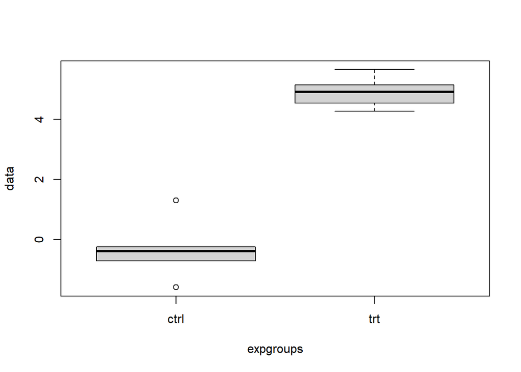

```r
boxplot(data ~ expgroups)
```

## Perform ANOVA

The model formula is written such that the dependent variable (data) is explained by the independent variable (groups). Best way to setup the data is to put them in a different columns of a dataframe.

```r
mydata = data.frame(data=data, expgroups=expgroups)
```

Two ways to perform an ANOVA analysis. The `lm()` function is for planned experiment and the `aov()` is for unplanned experiments. We will try both for all different scenarios.

Method 1: `aov`

```r
aov(data~expgroups, data=mydata)
```

```
## Call:
##    aov(formula = data ~ expgroups, data = mydata)
##
## Terms:
##                 expgroups Residuals
## Sum of Squares   68.55154   5.59723
## Deg. of Freedom         1         8
##
## Residual standard error: 0.8364533
## Estimated effects may be unbalanced
```

```r
summary(aov(data~expgroups, data=mydata))  # same as `summary.aov()`
```

```
##             Df Sum Sq Mean Sq F value   Pr(>F)
## expgroups    1  68.55   68.55   97.98 9.16e-06 ***
## Residuals    8   5.60    0.70
## ---
## Signif. codes:  0 '***' 0.001 '**' 0.01 '*' 0.05 '.' 0.1 ' ' 1
```

```r
                              # both expect a class 'aov' as the argument
```

Method 2: `lm()`

```r
datalm = lm(data ~ expgroups, data=mydata) # linear model of the data as explained by expgroups
                              # expgroups is the independent variable
                              # data is the dependent variable

summary(datalm)               # same as `summary.lm()`
```

```
##
## Call:
## lm(formula = data ~ expgroups, data = mydata)
##
## Residuals:
##      Min       1Q   Median       3Q      Max
## -1.26843 -0.37661 -0.02881  0.20077  1.63171
##
## Coefficients:
##              Estimate Std. Error t value Pr(>|t|)
## (Intercept)   -0.3288     0.3741  -0.879    0.405
## expgroupstrt   5.2365     0.5290   9.898 9.16e-06 ***
## ---
## Signif. codes:  0 '***' 0.001 '**' 0.01 '*' 0.05 '.' 0.1 ' ' 1
##
## Residual standard error: 0.8365 on 8 degrees of freedom
## Multiple R-squared:  0.9245, Adjusted R-squared:  0.9151
## F-statistic: 97.98 on 1 and 8 DF,  p-value: 9.16e-06
```

```r
                              # expects a class 'lm' as the argument
```

The results from looking at `summary.lm` and `summary.aov` are slightly different. The Null hypothesis of linear modeling is that the *slope* of the line is 0 ( or the difference of means is 0), whereas the Null hypothesis of the ANOVA is that the *variance* of all of the data is the same as the variance of the individual groups. In other words, the baseline for `lm` is the control, whereas for ANOVA there is no baseline; you simply look at all the differences between the groups.

Despite these methodological differences, **notice that the $p$-values are the same.**

Using the `anova()` function on the linear model gives you the same information as the summary of `aov()`:

```r
anova(datalm) # same as summary(aov(data ~ expgroups))
```

```
## Analysis of Variance Table
##
## Response: data
##           Df Sum Sq Mean Sq F value   Pr(>F)
## expgroups  1 68.552  68.552  97.979 9.16e-06 ***
## Residuals  8  5.597   0.700
## ---
## Signif. codes:  0 '***' 0.001 '**' 0.01 '*' 0.05 '.' 0.1 ' ' 1
```

### Generating random normally distributed data for three groups

Let’s make another group and call it `trt2`.

```r
trt2= rnorm(5,mean=10) # same number of samples, but mean differs
```

Let’s combine it with the other groups.

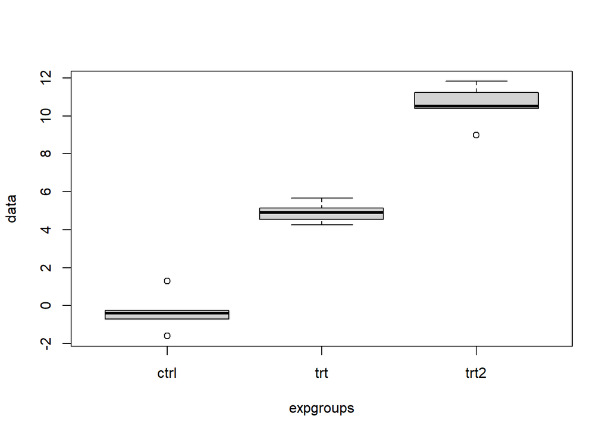

```r
data = c(ctrl,trt,trt2)
expgroups = factor(rep(c("ctrl", "trt", "trt2"), each=5))
mydata = data.frame(data=data, expgroups=expgroups)
boxplot(data ~ expgroups, data=mydata)
```

```r
datalm = lm(data ~ expgroups, data=mydata)
summary(datalm)
```

```
##
## Call:
## lm(formula = data ~ expgroups, data = mydata)
##
## Residuals:
##      Min       1Q   Median       3Q      Max
## -1.60212 -0.37252 -0.06367  0.44072  1.63171
##
## Coefficients:
##               Estimate Std. Error t value Pr(>|t|)
## (Intercept)    -0.3288     0.4109  -0.800    0.439
## expgroupstrt    5.2365     0.5811   9.011 1.09e-06 ***
## expgroupstrt2  10.9170     0.5811  18.786 2.89e-10 ***
## ---
## Signif. codes:  0 '***' 0.001 '**' 0.01 '*' 0.05 '.' 0.1 ' ' 1
##
## Residual standard error: 0.9188 on 12 degrees of freedom
## Multiple R-squared:  0.9671, Adjusted R-squared:  0.9617
## F-statistic: 176.6 on 2 and 12 DF,  p-value: 1.26e-09
```

For this model, “Estimate” gives the slope of the line between the control and each experimental group. This is around 5 comparing ctl-trt1 and ~10 comparing ctl-trt2. This is just the difference between the means.

We get $p$-values for the individual groups, and an overall $p$-value for the model.

Let’s compare this to the ANOVA result:

```r
summary(aov(data ~ expgroups, data=mydata))
```

```
##             Df Sum Sq Mean Sq F value   Pr(>F)
## expgroups    2 298.12  149.06   176.6 1.26e-09 ***
## Residuals   12  10.13    0.84
## ---
## Signif. codes:  0 '***' 0.001 '**' 0.01 '*' 0.05 '.' 0.1 ' ' 1
```

### Tukey’s honest significant difference test

Notice that for `summary` we don’t see which groups are giving the significant difference. We can use “Tukey’s honest significant difference” test, **TukeyHSD**, which performs a pair-wise comparison to help us figure this out.

```r
TukeyHSD(aov(data ~ expgroups, data=mydata))
```

```
##   Tukey multiple comparisons of means
##     95% family-wise confidence level
##
## Fit: aov(formula = data ~ expgroups, data = mydata)
##
## $expgroups
##                diff      lwr       upr   p adj
## trt-ctrl   5.236470 3.686151  6.786789 3.0e-06
## trt2-ctrl 10.917003 9.366684 12.467322 0.0e+00
## trt2-trt   5.680533 4.130214  7.230852 1.3e-06
```

This shows the magnitude of the differences between all pairwise combinations of the groups, so you can tell which groups are responsible for any major differences between them.

Again, performing the `anova()` function on the linear model gives you the same results as the summary of `aov()` however you can not perform `TukeyHSD()` on the `anova()` results.

```r
anova(datalm)
```

```
## Analysis of Variance Table
##
## Response: data
##           Df  Sum Sq Mean Sq F value   Pr(>F)
## expgroups  2 298.117 149.058  176.56 1.26e-09 ***
## Residuals 12  10.131   0.844
## ---
## Signif. codes:  0 '***' 0.001 '**' 0.01 '*' 0.05 '.' 0.1 ' ' 1
```

### What if trt2 is the same as trt?

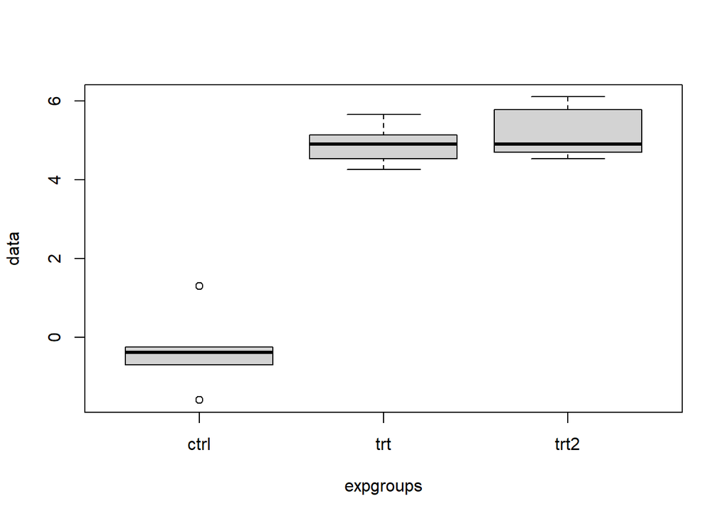

```r
trt2= rnorm(5,mean=5)
data = c(ctrl,trt,trt2)
expgroups = factor(rep(c("ctrl", "trt","trt2"), each=5))
mydata = data.frame(data=data, expgroups=expgroups)

datalm = lm(data ~ expgroups, data=mydata)
boxplot(data ~ expgroups, data=mydata)
```

```r
summary(datalm)
```

```
##
## Call:
## lm(formula = data ~ expgroups, data = mydata)
##
## Residuals:
##      Min       1Q   Median       3Q      Max
## -1.26843 -0.44627 -0.06367  0.41150  1.63171
##
## Coefficients:
##               Estimate Std. Error t value Pr(>|t|)
## (Intercept)    -0.3288     0.3548  -0.927    0.372
## expgroupstrt    5.2365     0.5018  10.436 2.25e-07 ***
## expgroupstrt2   5.5389     0.5018  11.039 1.22e-07 ***
## ---
## Signif. codes:  0 '***' 0.001 '**' 0.01 '*' 0.05 '.' 0.1 ' ' 1
##
## Residual standard error: 0.7934 on 12 degrees of freedom
## Multiple R-squared:  0.9277, Adjusted R-squared:  0.9157
## F-statistic: 77.04 on 2 and 12 DF,  p-value: 1.423e-07
```

```r
summary(aov(data~expgroups, data=mydata))
```

```
##             Df Sum Sq Mean Sq F value   Pr(>F)
## expgroups    2  96.99   48.49   77.04 1.42e-07 ***
## Residuals   12   7.55    0.63
## ---
## Signif. codes:  0 '***' 0.001 '**' 0.01 '*' 0.05 '.' 0.1 ' ' 1
```

```r
TukeyHSD(aov(data~expgroups, data=mydata))
```

```
##   Tukey multiple comparisons of means
##     95% family-wise confidence level
##
## Fit: aov(formula = data ~ expgroups, data = mydata)
##
## $expgroups
##                diff       lwr      upr     p adj
## trt-ctrl  5.2364699  3.897823 6.575117 0.0000006
## trt2-ctrl 5.5388938  4.200247 6.877541 0.0000003
## trt2-trt  0.3024238 -1.036223 1.641071 0.8213196
```

Notice that for the ANOVA, the differences between the groups is the same as the slopes between the ctl and the treatment groups in the linear model.

### What if trt2 is same as ctrl?

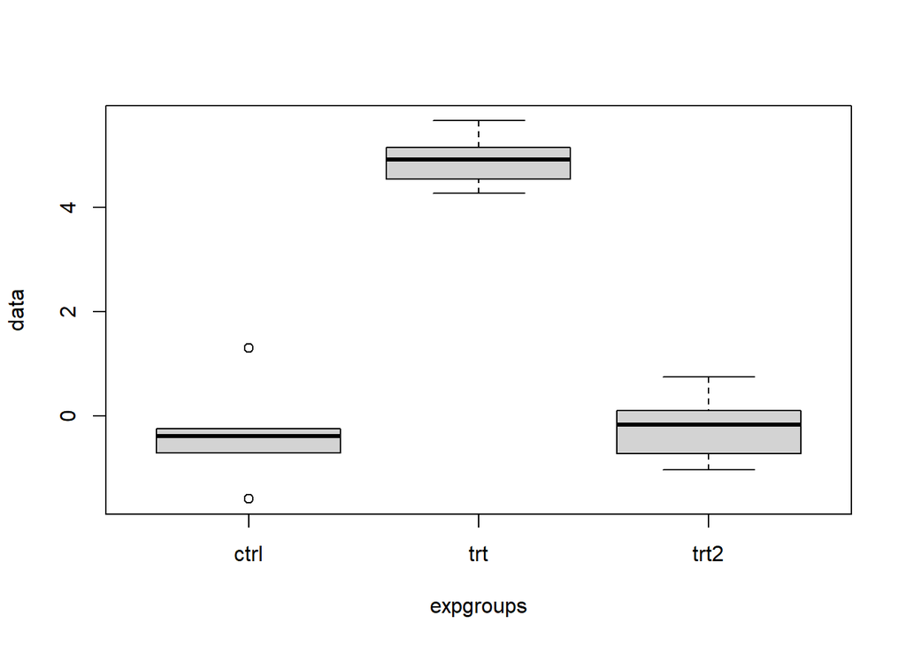

```r
trt2= rnorm(5,mean=0)
data = c(ctrl,trt,trt2)
expgroups = factor(rep(c("ctrl", "trt","trt2"), each=5))
mydata = data.frame(data=data, expgroups=expgroups)

datalm = lm(data ~ expgroups, data=mydata)
boxplot(data~expgroups, data=mydata)
```

```r
summary(datalm)
```

```
##
## Call:
## lm(formula = data ~ expgroups, data = mydata)
##
## Residuals:
##      Min       1Q   Median       3Q      Max
## -1.26843 -0.44746  0.00605  0.28120  1.63171
##
## Coefficients:
##               Estimate Std. Error t value Pr(>|t|)
## (Intercept)    -0.3288     0.3551  -0.926    0.373
## expgroupstrt    5.2365     0.5022  10.428 2.27e-07 ***
## expgroupstrt2   0.1093     0.5022   0.218    0.831
## ---
## Signif. codes:  0 '***' 0.001 '**' 0.01 '*' 0.05 '.' 0.1 ' ' 1
##
## Residual standard error: 0.794 on 12 degrees of freedom
## Multiple R-squared:  0.9221, Adjusted R-squared:  0.9091
## F-statistic: 71.01 on 2 and 12 DF,  p-value: 2.237e-07
```

```r
summary(aov(data~expgroups, data=mydata))
```

```
##             Df Sum Sq Mean Sq F value   Pr(>F)
## expgroups    2  89.53   44.77   71.01 2.24e-07 ***
## Residuals   12   7.57    0.63
## ---
## Signif. codes:  0 '***' 0.001 '**' 0.01 '*' 0.05 '.' 0.1 ' ' 1
```

```r
TukeyHSD(aov(data~expgroups, data=mydata))
```

```
##   Tukey multiple comparisons of means
##     95% family-wise confidence level
##
## Fit: aov(formula = data ~ expgroups, data = mydata)
##
## $expgroups
##                diff       lwr       upr     p adj
## trt-ctrl   5.236470  3.896731  6.576209 0.0000006
## trt2-ctrl  0.109267 -1.230472  1.449006 0.9742937
## trt2-trt  -5.127203 -6.466942 -3.787464 0.0000008
```